# Risk Factor Analysis

## Outcome Variable

**Outcome Variable:** ever_sstunted

## Predictor Variables

**Intervention Variable:** fhtcm

**Adjustment Set:**

unadjusted

## Stratifying Variables

The analysis was stratified on these variable(s):

- agecat
- studyid
- country

## Data Summary

| agecat | studyid | country | fhtcm | ever_sstunted | n_cell | n |
| --- | --- | --- | --- | --- | --- | --- |
| 0-24 months | COHORTS | GUATEMALA | >=167 cm | 0 | 37 | 496 |
| 0-24 months | COHORTS | GUATEMALA | >=167 cm | 1 | 27 | 496 |
| 0-24 months | COHORTS | GUATEMALA | <162 cm | 0 | 103 | 496 |
| 0-24 months | COHORTS | GUATEMALA | <162 cm | 1 | 190 | 496 |
| 0-24 months | COHORTS | GUATEMALA | [162-167) cm | 0 | 77 | 496 |
| 0-24 months | COHORTS | GUATEMALA | [162-167) cm | 1 | 62 | 496 |
| 0-24 months | Keneba | GAMBIA | >=167 cm | 0 | 972 | 1929 |
| 0-24 months | Keneba | GAMBIA | >=167 cm | 1 | 273 | 1929 |
| 0-24 months | Keneba | GAMBIA | <162 cm | 0 | 98 | 1929 |
| 0-24 months | Keneba | GAMBIA | <162 cm | 1 | 34 | 1929 |
| 0-24 months | Keneba | GAMBIA | [162-167) cm | 0 | 413 | 1929 |
| 0-24 months | Keneba | GAMBIA | [162-167) cm | 1 | 139 | 1929 |
| 0-24 months | PROBIT | BELARUS | >=167 cm | 0 | 11452 | 12537 |
| 0-24 months | PROBIT | BELARUS | >=167 cm | 1 | 292 | 12537 |
| 0-24 months | PROBIT | BELARUS | <162 cm | 0 | 154 | 12537 |
| 0-24 months | PROBIT | BELARUS | <162 cm | 1 | 14 | 12537 |
| 0-24 months | PROBIT | BELARUS | [162-167) cm | 0 | 597 | 12537 |
| 0-24 months | PROBIT | BELARUS | [162-167) cm | 1 | 28 | 12537 |
| 0-24 months | SAS-CompFeed | INDIA | >=167 cm | 0 | 307 | 907 |
| 0-24 months | SAS-CompFeed | INDIA | >=167 cm | 1 | 103 | 907 |
| 0-24 months | SAS-CompFeed | INDIA | <162 cm | 0 | 130 | 907 |
| 0-24 months | SAS-CompFeed | INDIA | <162 cm | 1 | 100 | 907 |
| 0-24 months | SAS-CompFeed | INDIA | [162-167) cm | 0 | 159 | 907 |
| 0-24 months | SAS-CompFeed | INDIA | [162-167) cm | 1 | 108 | 907 |
| 0-24 months | SAS-FoodSuppl | INDIA | >=167 cm | 0 | 62 | 399 |
| 0-24 months | SAS-FoodSuppl | INDIA | >=167 cm | 1 | 44 | 399 |
| 0-24 months | SAS-FoodSuppl | INDIA | <162 cm | 0 | 69 | 399 |
| 0-24 months | SAS-FoodSuppl | INDIA | <162 cm | 1 | 94 | 399 |
| 0-24 months | SAS-FoodSuppl | INDIA | [162-167) cm | 0 | 72 | 399 |
| 0-24 months | SAS-FoodSuppl | INDIA | [162-167) cm | 1 | 58 | 399 |
| 0-6 months | COHORTS | GUATEMALA | >=167 cm | 0 | 44 | 337 |
| 0-6 months | COHORTS | GUATEMALA | >=167 cm | 1 | 5 | 337 |
| 0-6 months | COHORTS | GUATEMALA | <162 cm | 0 | 166 | 337 |
| 0-6 months | COHORTS | GUATEMALA | <162 cm | 1 | 30 | 337 |
| 0-6 months | COHORTS | GUATEMALA | [162-167) cm | 0 | 86 | 337 |
| 0-6 months | COHORTS | GUATEMALA | [162-167) cm | 1 | 6 | 337 |
| 0-6 months | Keneba | GAMBIA | >=167 cm | 0 | 987 | 1723 |
| 0-6 months | Keneba | GAMBIA | >=167 cm | 1 | 126 | 1723 |
| 0-6 months | Keneba | GAMBIA | <162 cm | 0 | 116 | 1723 |
| 0-6 months | Keneba | GAMBIA | <162 cm | 1 | 8 | 1723 |
| 0-6 months | Keneba | GAMBIA | [162-167) cm | 0 | 431 | 1723 |
| 0-6 months | Keneba | GAMBIA | [162-167) cm | 1 | 55 | 1723 |
| 0-6 months | PROBIT | BELARUS | >=167 cm | 0 | 11642 | 12537 |
| 0-6 months | PROBIT | BELARUS | >=167 cm | 1 | 102 | 12537 |
| 0-6 months | PROBIT | BELARUS | <162 cm | 0 | 164 | 12537 |
| 0-6 months | PROBIT | BELARUS | <162 cm | 1 | 4 | 12537 |
| 0-6 months | PROBIT | BELARUS | [162-167) cm | 0 | 617 | 12537 |
| 0-6 months | PROBIT | BELARUS | [162-167) cm | 1 | 8 | 12537 |
| 0-6 months | SAS-CompFeed | INDIA | >=167 cm | 0 | 372 | 905 |
| 0-6 months | SAS-CompFeed | INDIA | >=167 cm | 1 | 38 | 905 |
| 0-6 months | SAS-CompFeed | INDIA | <162 cm | 0 | 178 | 905 |
| 0-6 months | SAS-CompFeed | INDIA | <162 cm | 1 | 51 | 905 |
| 0-6 months | SAS-CompFeed | INDIA | [162-167) cm | 0 | 222 | 905 |
| 0-6 months | SAS-CompFeed | INDIA | [162-167) cm | 1 | 44 | 905 |
| 0-6 months | SAS-FoodSuppl | INDIA | >=167 cm | 0 | 99 | 397 |
| 0-6 months | SAS-FoodSuppl | INDIA | >=167 cm | 1 | 7 | 397 |
| 0-6 months | SAS-FoodSuppl | INDIA | <162 cm | 0 | 138 | 397 |
| 0-6 months | SAS-FoodSuppl | INDIA | <162 cm | 1 | 24 | 397 |
| 0-6 months | SAS-FoodSuppl | INDIA | [162-167) cm | 0 | 114 | 397 |
| 0-6 months | SAS-FoodSuppl | INDIA | [162-167) cm | 1 | 15 | 397 |

The following strata were considered:

- agecat: 0-24 months, studyid: COHORTS, country: GUATEMALA
- agecat: 0-24 months, studyid: Keneba, country: GAMBIA
- agecat: 0-24 months, studyid: PROBIT, country: BELARUS
- agecat: 0-24 months, studyid: SAS-CompFeed, country: INDIA
- agecat: 0-24 months, studyid: SAS-FoodSuppl, country: INDIA
- agecat: 0-6 months, studyid: COHORTS, country: GUATEMALA
- agecat: 0-6 months, studyid: Keneba, country: GAMBIA
- agecat: 0-6 months, studyid: PROBIT, country: BELARUS
- agecat: 0-6 months, studyid: SAS-CompFeed, country: INDIA
- agecat: 0-6 months, studyid: SAS-FoodSuppl, country: INDIA

### Dropped Strata

Some strata were dropped due to rare outcomes:

- agecat: 0-6 months, studyid: PROBIT, country: BELARUS

## Methods Detail

We’re interested in the causal parameters $E[Y_a]$ for all values of $a \in \mathcal{A}$. These parameters represent the mean outcome if, possibly contrary to fact, we intervened to set all units to have $A=a$. Under the randomization and positivity assumptions, these are identified by the statistical parameters $\psi_a=E_W[E_{Y|A,W}(Y|A=a,W)]$. In addition, we’re interested in the mean of $Y$, $E[Y]$ under no intervention (the observed mean). We will estimate these parameters by using SuperLearner to fit the relevant likelihood factors – $E_{Y|A,W}(Y|A=a,W)$ and $p(A=a|W)$, and then updating our likelihood fit using a joint TMLE.

For unadjusted analyses ($W=\{\}$), initial likelihoods were estimated using Lrnr_glm to estimate the simple $E(Y|A)$ and Lrnr_mean to estimate $p(A)$. For adjusted analyses, a small library containing Lrnr_glmnet, Lrnr_xgboost, and Lrnr_mean was used.

Having estimated these parameters, we will then use the delta method to estimate relative risks and attributable risks relative to a prespecified baseline level of $A$.

# Results Detail

## Results Plots

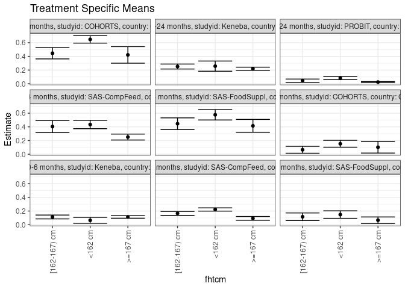

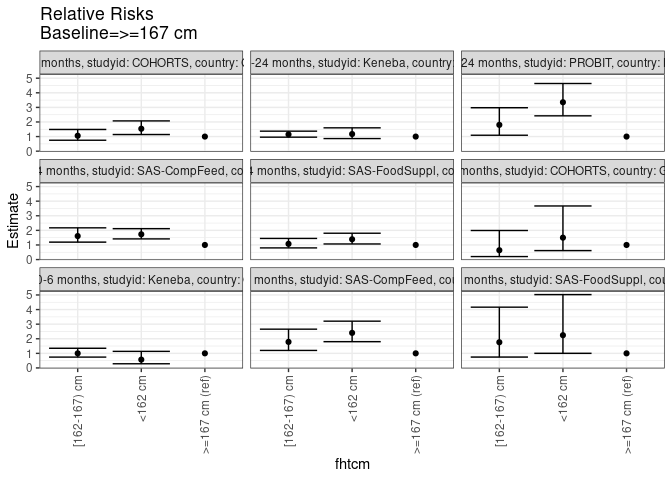

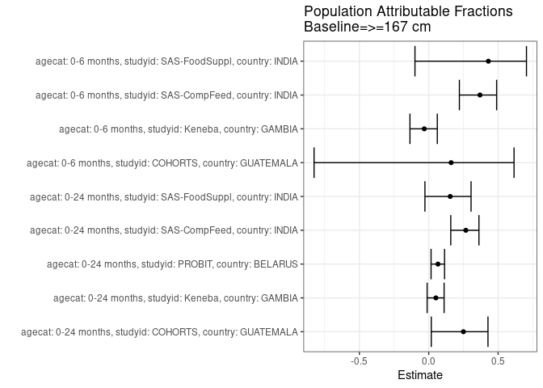

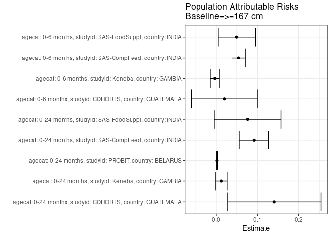

## Results Table

### Parameter: TSM

| agecat | studyid | country | intervention_level | baseline_level | estimate | ci_lower | ci_upper |
| --- | --- | --- | --- | --- | --- | --- | --- |
| 0-24 months | COHORTS | GUATEMALA | >=167 cm | NA | 0.4218750 | 0.3007597 | 0.5429903 |
| 0-24 months | COHORTS | GUATEMALA | <162 cm | NA | 0.6484642 | 0.5937399 | 0.7031885 |
| 0-24 months | COHORTS | GUATEMALA | [162-167) cm | NA | 0.4460432 | 0.3633242 | 0.5287622 |
| 0-24 months | Keneba | GAMBIA | >=167 cm | NA | 0.2192771 | 0.1962881 | 0.2422662 |
| 0-24 months | Keneba | GAMBIA | <162 cm | NA | 0.2575758 | 0.1829563 | 0.3321952 |
| 0-24 months | Keneba | GAMBIA | [162-167) cm | NA | 0.2518116 | 0.2155928 | 0.2880304 |
| 0-24 months | PROBIT | BELARUS | >=167 cm | NA | 0.0248638 | 0.0181909 | 0.0315366 |
| 0-24 months | PROBIT | BELARUS | <162 cm | NA | 0.0833333 | 0.0598693 | 0.1067973 |
| 0-24 months | PROBIT | BELARUS | [162-167) cm | NA | 0.0448000 | 0.0206419 | 0.0689581 |
| 0-24 months | SAS-CompFeed | INDIA | >=167 cm | NA | 0.2512195 | 0.2079447 | 0.2944943 |
| 0-24 months | SAS-CompFeed | INDIA | <162 cm | NA | 0.4347826 | 0.3734136 | 0.4961517 |
| 0-24 months | SAS-CompFeed | INDIA | [162-167) cm | NA | 0.4044944 | 0.3156875 | 0.4933013 |
| 0-24 months | SAS-FoodSuppl | INDIA | >=167 cm | NA | 0.4150943 | 0.3211747 | 0.5090140 |
| 0-24 months | SAS-FoodSuppl | INDIA | <162 cm | NA | 0.5766871 | 0.5007420 | 0.6526323 |
| 0-24 months | SAS-FoodSuppl | INDIA | [162-167) cm | NA | 0.4461538 | 0.3605963 | 0.5317114 |
| 0-6 months | COHORTS | GUATEMALA | >=167 cm | NA | 0.1020408 | 0.0171598 | 0.1869218 |
| 0-6 months | COHORTS | GUATEMALA | <162 cm | NA | 0.1530612 | 0.1025807 | 0.2035418 |
| 0-6 months | COHORTS | GUATEMALA | [162-167) cm | NA | 0.0652174 | 0.0146889 | 0.1157459 |
| 0-6 months | Keneba | GAMBIA | >=167 cm | NA | 0.1132075 | 0.0945877 | 0.1318274 |
| 0-6 months | Keneba | GAMBIA | <162 cm | NA | 0.0645161 | 0.0212632 | 0.1077691 |
| 0-6 months | Keneba | GAMBIA | [162-167) cm | NA | 0.1131687 | 0.0849953 | 0.1413422 |
| 0-6 months | SAS-CompFeed | INDIA | >=167 cm | NA | 0.0926829 | 0.0652923 | 0.1200735 |
| 0-6 months | SAS-CompFeed | INDIA | <162 cm | NA | 0.2227074 | 0.1989933 | 0.2464216 |
| 0-6 months | SAS-CompFeed | INDIA | [162-167) cm | NA | 0.1654135 | 0.1362937 | 0.1945333 |
| 0-6 months | SAS-FoodSuppl | INDIA | >=167 cm | NA | 0.0660377 | 0.0187004 | 0.1133750 |
| 0-6 months | SAS-FoodSuppl | INDIA | <162 cm | NA | 0.1481481 | 0.0933749 | 0.2029214 |
| 0-6 months | SAS-FoodSuppl | INDIA | [162-167) cm | NA | 0.1162791 | 0.0608919 | 0.1716662 |

### Parameter: E(Y)

| agecat | studyid | country | intervention_level | baseline_level | estimate | ci_lower | ci_upper |
| --- | --- | --- | --- | --- | --- | --- | --- |
| 0-24 months | COHORTS | GUATEMALA | NA | NA | 0.5625000 | 0.5187986 | 0.6062014 |
| 0-24 months | Keneba | GAMBIA | NA | NA | 0.2312079 | 0.2123887 | 0.2500270 |
| 0-24 months | PROBIT | BELARUS | NA | NA | 0.0266411 | 0.0195656 | 0.0337167 |
| 0-24 months | SAS-CompFeed | INDIA | NA | NA | 0.3428886 | 0.3091585 | 0.3766188 |
| 0-24 months | SAS-FoodSuppl | INDIA | NA | NA | 0.4912281 | 0.4421136 | 0.5403426 |
| 0-6 months | COHORTS | GUATEMALA | NA | NA | 0.1216617 | 0.0867086 | 0.1566149 |
| 0-6 months | Keneba | GAMBIA | NA | NA | 0.1096924 | 0.0949323 | 0.1244525 |
| 0-6 months | SAS-CompFeed | INDIA | NA | NA | 0.1469613 | 0.1306617 | 0.1632610 |
| 0-6 months | SAS-FoodSuppl | INDIA | NA | NA | 0.1158690 | 0.0843449 | 0.1473931 |

### Parameter: RR

| agecat | studyid | country | intervention_level | baseline_level | estimate | ci_lower | ci_upper |
| --- | --- | --- | --- | --- | --- | --- | --- |
| 0-24 months | COHORTS | GUATEMALA | >=167 cm | >=167 cm | 1.0000000 | 1.0000000 | 1.000000 |
| 0-24 months | COHORTS | GUATEMALA | <162 cm | >=167 cm | 1.5371002 | 1.1395836 | 2.073281 |
| 0-24 months | COHORTS | GUATEMALA | [162-167) cm | >=167 cm | 1.0572875 | 0.7512097 | 1.488076 |
| 0-24 months | Keneba | GAMBIA | >=167 cm | >=167 cm | 1.0000000 | 1.0000000 | 1.000000 |
| 0-24 months | Keneba | GAMBIA | <162 cm | >=167 cm | 1.1746587 | 0.8632003 | 1.598497 |
| 0-24 months | Keneba | GAMBIA | [162-167) cm | >=167 cm | 1.1483716 | 0.9611332 | 1.372086 |
| 0-24 months | PROBIT | BELARUS | >=167 cm | >=167 cm | 1.0000000 | 1.0000000 | 1.000000 |
| 0-24 months | PROBIT | BELARUS | <162 cm | >=167 cm | 3.3515982 | 2.4224619 | 4.637105 |
| 0-24 months | PROBIT | BELARUS | [162-167) cm | >=167 cm | 1.8018192 | 1.0909253 | 2.975962 |
| 0-24 months | SAS-CompFeed | INDIA | >=167 cm | >=167 cm | 1.0000000 | 1.0000000 | 1.000000 |
| 0-24 months | SAS-CompFeed | INDIA | <162 cm | >=167 cm | 1.7306881 | 1.4156314 | 2.115862 |
| 0-24 months | SAS-CompFeed | INDIA | [162-167) cm | >=167 cm | 1.6101233 | 1.1932303 | 2.172671 |
| 0-24 months | SAS-FoodSuppl | INDIA | >=167 cm | >=167 cm | 1.0000000 | 1.0000000 | 1.000000 |
| 0-24 months | SAS-FoodSuppl | INDIA | <162 cm | >=167 cm | 1.3892917 | 1.0692940 | 1.805052 |
| 0-24 months | SAS-FoodSuppl | INDIA | [162-167) cm | >=167 cm | 1.0748252 | 0.7989660 | 1.445930 |
| 0-6 months | COHORTS | GUATEMALA | >=167 cm | >=167 cm | 1.0000000 | 1.0000000 | 1.000000 |
| 0-6 months | COHORTS | GUATEMALA | <162 cm | >=167 cm | 1.5000000 | 0.6130158 | 3.670378 |
| 0-6 months | COHORTS | GUATEMALA | [162-167) cm | >=167 cm | 0.6391304 | 0.2050700 | 1.991943 |
| 0-6 months | Keneba | GAMBIA | >=167 cm | >=167 cm | 1.0000000 | 1.0000000 | 1.000000 |
| 0-6 months | Keneba | GAMBIA | <162 cm | >=167 cm | 0.5698925 | 0.2857583 | 1.136546 |
| 0-6 months | Keneba | GAMBIA | [162-167) cm | >=167 cm | 0.9996571 | 0.7417675 | 1.347207 |
| 0-6 months | SAS-CompFeed | INDIA | >=167 cm | >=167 cm | 1.0000000 | 1.0000000 | 1.000000 |
| 0-6 months | SAS-CompFeed | INDIA | <162 cm | >=167 cm | 2.4028959 | 1.8008228 | 3.206261 |
| 0-6 months | SAS-CompFeed | INDIA | [162-167) cm | >=167 cm | 1.7847250 | 1.1992283 | 2.656077 |
| 0-6 months | SAS-FoodSuppl | INDIA | >=167 cm | >=167 cm | 1.0000000 | 1.0000000 | 1.000000 |
| 0-6 months | SAS-FoodSuppl | INDIA | <162 cm | >=167 cm | 2.2433862 | 1.0014353 | 5.025568 |
| 0-6 months | SAS-FoodSuppl | INDIA | [162-167) cm | >=167 cm | 1.7607973 | 0.7446161 | 4.163766 |

### Parameter: PAR

| agecat | studyid | country | intervention_level | baseline_level | estimate | ci_lower | ci_upper |
| --- | --- | --- | --- | --- | --- | --- | --- |
| 0-24 months | COHORTS | GUATEMALA | >=167 cm | NA | 0.1406250 | 0.0275179 | 0.2537321 |
| 0-24 months | Keneba | GAMBIA | >=167 cm | NA | 0.0119308 | -0.0022277 | 0.0260892 |
| 0-24 months | PROBIT | BELARUS | >=167 cm | NA | 0.0017774 | 0.0003809 | 0.0031739 |
| 0-24 months | SAS-CompFeed | INDIA | >=167 cm | NA | 0.0916691 | 0.0561036 | 0.1272347 |
| 0-24 months | SAS-FoodSuppl | INDIA | >=167 cm | NA | 0.0761337 | -0.0047757 | 0.1570432 |
| 0-6 months | COHORTS | GUATEMALA | >=167 cm | NA | 0.0196209 | -0.0599489 | 0.0991907 |
| 0-6 months | Keneba | GAMBIA | >=167 cm | NA | -0.0035152 | -0.0143156 | 0.0072853 |
| 0-6 months | SAS-CompFeed | INDIA | >=167 cm | NA | 0.0542784 | 0.0379381 | 0.0706187 |
| 0-6 months | SAS-FoodSuppl | INDIA | >=167 cm | NA | 0.0498313 | 0.0046873 | 0.0949753 |

### Parameter: PAF

| agecat | studyid | country | intervention_level | baseline_level | estimate | ci_lower | ci_upper |
| --- | --- | --- | --- | --- | --- | --- | --- |
| 0-24 months | COHORTS | GUATEMALA | >=167 cm | NA | 0.2500000 | 0.0182489 | 0.4270442 |
| 0-24 months | Keneba | GAMBIA | >=167 cm | NA | 0.0516019 | -0.0115891 | 0.1108456 |
| 0-24 months | PROBIT | BELARUS | >=167 cm | NA | 0.0667157 | 0.0168714 | 0.1140328 |
| 0-24 months | SAS-CompFeed | INDIA | >=167 cm | NA | 0.2673437 | 0.1588000 | 0.3618816 |
| 0-24 months | SAS-FoodSuppl | INDIA | >=167 cm | NA | 0.1549865 | -0.0274292 | 0.3050151 |
| 0-6 months | COHORTS | GUATEMALA | >=167 cm | NA | 0.1612743 | -0.8265131 | 0.6148613 |
| 0-6 months | Keneba | GAMBIA | >=167 cm | NA | -0.0320455 | -0.1352786 | 0.0618004 |
| 0-6 months | SAS-CompFeed | INDIA | >=167 cm | NA | 0.3693380 | 0.2209386 | 0.4894695 |
| 0-6 months | SAS-FoodSuppl | INDIA | >=167 cm | NA | 0.4300656 | -0.0992516 | 0.7045033 |